# Tidymodels-01

John Yuill

2020-11-07

## Objective

Explorations and examples of using ‘tidymodels’ pkg/approach and/or related components.

Reference:

- [tidymodels learning doc](https://www.tidymodels.org/learn/)
- video: [Predictive modeling with tidymodels and NFL attendance - Julia Silge](https://www.youtube.com/watch?v=LPptRkGoYMg&t=141s)

Using website data to answer questions: **NEED TO REVISIT: NOT ENOUGH DATA**

- can we predict bounce rate based on channel?
- can we predict pageviews per session by channel?

### Get/Clean/Explore

Get data, clean it up, explore it to understand it better and determine whethe/how it will be suitable for prediction.

#### Import and check

```
## Rows: 848
## Columns: 18
## $ product         <chr> "an", "an", "an", "an", "an", "an", "an", "an"...
## $ forums          <dbl> 9846, 11225, 5417, 3081, 5731, 3625, 3098, 284...
## $ news            <dbl> 1157, 1024, 322, 453, 414, 156, 19, 442, 499, ...
## $ twitter         <dbl> 68208, 30771, 14012, 3302, 5846, 3631, 1971, 2...
## $ video           <dbl> 26078, 58471, 11300, 7055, 17857, 7998, 4534, ...
## $ convo_vol       <dbl> 105289, 101491, 31051, 13891, 29848, 15410, 96...
## $ positive_vol    <dbl> 32376, 40055, 8621, 4166, 9988, 4471, 2383, 23...
## $ neutral_vol     <dbl> 49905, 36595, 16012, 4813, 9098, 5860, 3701, 3...
## $ negative_vol    <dbl> 23008, 24841, 6418, 4912, 10762, 5079, 3538, 3...
## $ senti_score_avg <dbl> 65.00000, 83.14286, 70.85714, 53.14286, 55.714...
## $ senti_score_wk  <dbl> 73, 81, 71, 48, 56, 33, 43, 33, 43, 59, 64, 77...
## $ week            <dbl> -37, -36, -35, -34, -33, -32, -31, -30, -29, -...
## $ units           <dbl> 5112, 46104, 12668, 10730, 7899, 7343, 5953, 5...
## $ index           <dbl> 3.6928667, 3.7443667, 1.6105667, 1.2555000, 1....
## $ views           <dbl> 6428505, 26781995, 4503416, 2356591, 5486643, ...
## $ group           <chr> "an", "an", "an", "an", "an", "an", "an", "an"...
## $ cat             <chr> "Action", "Action", "Action", "Action", "Actio...
## $ period          <chr> "prelaunch", "prelaunch", "prelaunch", "prelau...
```

```
##
## Any NAs? TRUE
```

If NAs are found, determine where and take a look

```
## # A tibble: 1 x 18
##   product forums  news twitter video convo_vol positive_vol neutral_vol
##     <int>  <int> <int>   <int> <int>     <int>        <int>       <int>
## 1       0      0     0       0     0         0            0           0
## # ... with 10 more variables: negative_vol <int>, senti_score_avg <int>,
## #   senti_score_wk <int>, week <int>, units <int>, index <int>,
## #   views <int>, group <int>, cat <int>, period <int>
```

```
## # A tibble: 17 x 7
##    product convo_vol senti_score_wk  week units index     views
##    <chr>       <dbl>          <dbl> <dbl> <dbl> <dbl>     <dbl>
##  1 an           8076             57    71  3545    NA   1855843
##  2 g1           6405             58    92  4902    NA  13449530
##  3 g2          91939             72    40 92444    NA 105671470
##  4 g3          19726             60   -14 25277    NA  24943286
##  5 p1            961             48    99  1586    NA    403302
##  6 p2          53704             68    48 26441    NA   9596869
##  7 p3          20911             61   -16   141    NA   4351828
##  8 p3           8009             54   -15   308    NA   2503859
##  9 p3           4692             47   -14   464    NA   2279759
## 10 p3          13940             53   -13   521    NA   4450712
## 11 p3         208116             56    -8 20837    NA   7910102
## 12 n1            466             66    94  1064    NA    156469
## 13 n2           7824             62    42 12910    NA   2278774
## 14 n3            184             46   -15    54    NA     17919
## 15 oj          16741             85    33 66964    NA   6037719
## 16 os         170882             76   -15 30528    NA  31730643
## 17 os           9189             71   -13  9886    NA   1222969
```

In this case:

- all NAs are one metric: index
- relatively few (only 17)
- mostly low or high week numbers, so shouldn’t affect results
- MAY be something to deal with later through imputation - OR even removal

#### Clean / Simplify

- Doesn’t look like any cleaning needed
- Re-arrange group, cat, period, week and move units to end
- Can remove some variables to simplify

#### Viz

Initial visualization

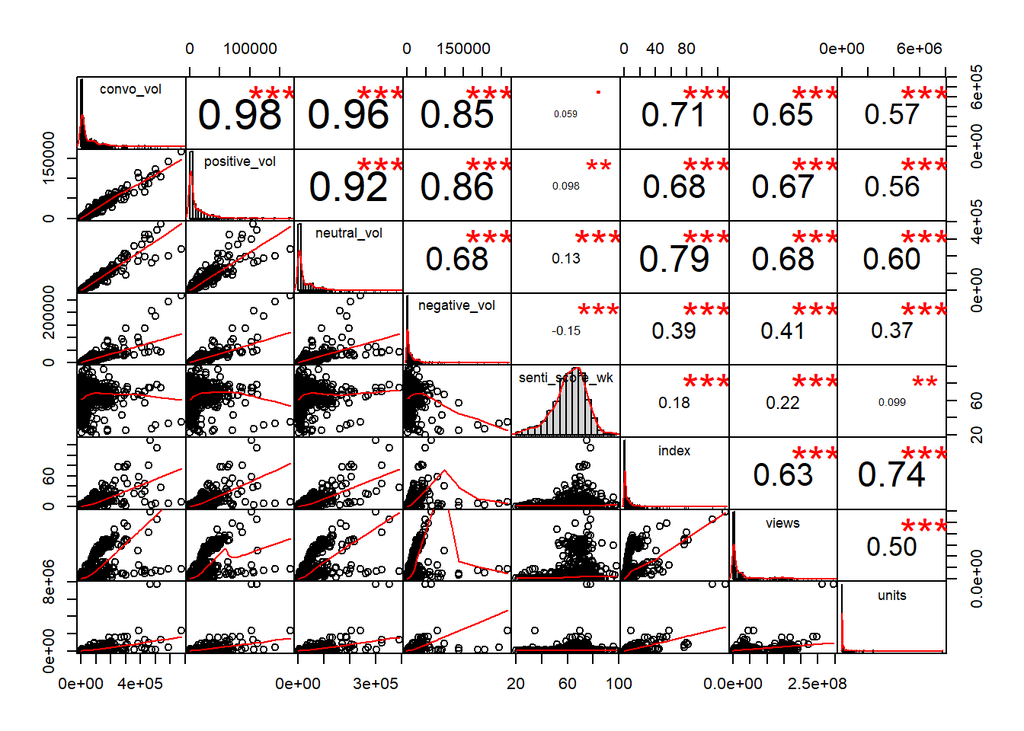

Initial observations:

- some strong correlations throughout
- scatterplots are messy - possibly due to categorical variables
- most variables very right skewed with high concentration of low values and long tail (exception being sentiment)
- looks like big differences in scale -> may need to center/standardize/normalize